# Introduction to Programming

Hugo Lhuillier

Master in Economics, Sciences Po

# Object-oriented programming language in a nutshell

# Looks complicated, but `err`

- OOP: programming methodology based on objects, instead of just functions
- Oject: pretty much anything and everything
- Classes: a category of objects; defines the common properties of the objects that belong to this class
- An object: an instance of a class $\Rightarrow$ different objects from an identical class have similar structure, but can be assigned individual characteristics
- Can create relationships between objects (e.g. can inherit properties from one another etc.)
- Can create functions that apply only on some objects

# OOP: an example

- Let’s `Human` be a class, with three characteristics

```yaml
Human:
  - Name        # will have to be a string
  - Age         # will have to be a numeric
  - Address     # would be nice to have a common structure for addresses
```

- Let’s `Address` be another class

```yaml
Address:
  - Number       # will have to be a numeric
  - Street       # will have to be a string
  - City         # will have to be a string
```

- Then, create my own address and human (two objects)

```julia
fredo-address = Address("27", "rue Saint-Guillaume", "Paris")
fredo-mion    = Human("Frédéric Mion", 49, fredo-address)
```

- And could also define functions

```julia
function where-i-live(address)
  "address.numer, address.street, address.city"

function presentation(human)
  "Hello, I am human.name. I am human.age, and I live where-i-live(human.address)"
```

# Useful?

- OOP languages are more flexible and allows you to write code that is extremely reusable
- **Example**: two functions can have the same names, but apply on different objects, and therefore produce different output

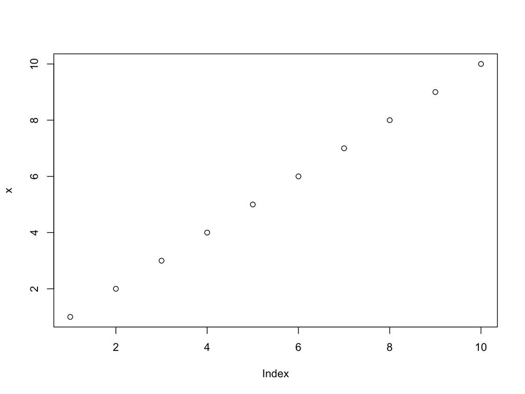

```r
x <- 1:10
plot(x)
```

# Useful?

- **Example**: two functions can have the same names, but apply on different objects, and therefore produce different output

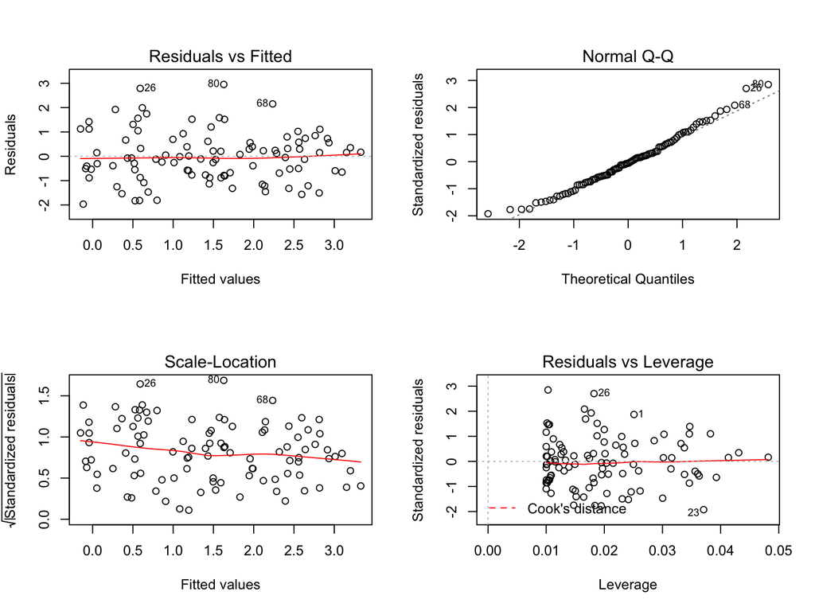

```r
x   <- runif(100); y <- 3 * x + rnorm(100)
reg <- lm(y ~ x + y)
par(mfrow=c(2,2))
plot(reg)
```

# R and OOP

# `R`’s raw classes

```r
x <- 2.0
```

- `x`: instance of the numeric class, with zero attribute

# `R` raw classes

- `R` has several functions to examine what objects we are dealing with
  - `class()` and `typeof()`: what kind of object is it
  - `length()`: how long is it
  - `attributes()`: what are its attributes

```r
x <- 1:10
typeof(x)
```

```
## [1] "integer"
```

```r
length(x)
```

```
## [1] 10
```

```r
attributes(x)
```

[output not shown]

# `R`’s data type

# `R`’s special values

- `R` contains certain objects that makes life of data scientist easier
  - `NA`: missing value - can be incorporated in any vector, regardless of the data the latter contains
  - `Inf`: infinity
  - `NaN`: not a number, i.e. an undefined value

```r
x <- c(1, NA)
```

```r
1 / 0
```

```
## [1] Inf
```

```r
0 / 0
```

```
## [1] NaN
```

# Data structures

- Data structures are other classes that groups together `R`’s raw classes
  - atomic vector
  - list
  - matrix
  - data frame
  - factors

# Atomic vectors

- Vectors are the most basic structures in `R`
- A vector is a collection of elements, that can be `character`, `logical`, `integer` etc.

```r
vector()                        # create an empty logical (by default) vector
```

```
## logical(0)
```

```r
logical(0)                      # id. to the above constructor
```

```
## logical(0)
```

```r
vector("numeric", length = 5)   # create a numeric vector of length 5
```

```
## [1] 0 0 0 0 0
```

```r
numeric(5)                      # id. to the above constructor
```

```
## [1] 0 0 0 0 0
```

- Alternatively, can directly create a vector with its content, and `R` will guess the appropriate mode of storage

```r
x <- c(1.0, 2.0, 3.0)
x <- c(x, 4.0)          # and can combine vectors via the function c()
```

# Note: `R`’s coercion

- Remember: `R` is an interpreted languages

```r
x <- c(1.0, 2.0)
x <- c("a", "b")
```

- “Coercion”: conversion between the different modes of storage
- Above = implicit coercion, and below explicit coercion

```r
x <- 1:10
typeof(x)
```

```
## [1] "integer"
```

```r
y <- as.numeric(x)
typeof(y)
```

```
## [1] "double"
```

```r
z <- as.character(y)
typeof(z)
```

```
## [1] "character"
```

# Matrix

- Matrix: extension of vectors $\Leftrightarrow$ an atomic vector with dimensions
- Created via the constructor `matrix`
- Matrix are filled column-wise by default, but can change this by setting `byrow = TRUE`

```r
x <- matrix(1:10, ncol = 5, nrow = 2); print(x)
```

```
##      [,1] [,2] [,3] [,4] [,5]
## [1,]    1    3    5    7    9
## [2,]    2    4    6    8   10
```

```r
x <- matrix(1:10, ncol = 5, nrow = 2, byrow = TRUE); print(x)
```

```
##      [,1] [,2] [,3] [,4] [,5]
## [1,]    1    2    3    4    5
## [2,]    6    7    8    9   10
```

```r
dim(x)
```

```
## [1] 2 5
```

- Note: if apply `dim()` to an object that isn’t a matrix, returns `NULL`

# Matrix

- Can also create matrices by combining rows and/or columns via `cbind` and `rbind`

```r
x <- 1:3; y <- 10:12
cbind(x,y)
```

```
##      x  y
## [1,] 1 10
## [2,] 2 11
## [3,] 3 12
```

```r
rbind(x,y)
```

```
##   [,1] [,2] [,3]
## x    1    2    3
## y   10   11   12
```

- **Question**: what happens if one vector is longer than another?

# List

- Lists (aka generic vector)
- Unlike atomic vector, not restricted to a single to a single data type
- As you guessed, create list via the corresponding constructor `list`

```r
x <- list(1, "a", TRUE, c(1, 2, 3)); print(x)
```

```
## [[1]]
## [1] 1
##
## [[2]]
## [1] "a"
##
## [[3]]
## [1] TRUE
##
## [[4]]
## [1] 1 2 3
```

- The elements in a list are retrieved by using doubel square brackets

```r
x[[4]]
```

```
## [1] 1 2 3
```

# List

- Elements of list can be named

```r
x <- list(a = "Fredo", b = "Mion", c = matrix(1:16, nrow = 4, ncol = 4)); print(x)
```

```
## $a
## [1] "Fredo"
##
## $b
## [1] "Mion"
##
## $c
##      [,1] [,2] [,3] [,4]
## [1,]    1    5    9   13
## [2,]    2    6   10   14
## [3,]    3    7   11   15
## [4,]    4    8   12   16
```

```r
names(x)
```

```
## [1] "a" "b" "c"
```

```r
attributes(x)
```

```
## $names
## [1] "a" "b" "c"
```

- When named, `x[[3]] == x$c`

# List: exercice

- What’s the class of `x[[3]]`?
- A matrix!
- What’s the class of `x <- c("a", 1.0)`?
- A vector of character! `1.0` $\Rightarrow$ `"1.0"`. Atomic vectors can only contains one type of class; `R`picks the class that can accomodate both types
- What’s the class of `x <- c(TRUE, 1.0)`?
- A vector of numeric, with `TRUE` $\Rightarrow$ `1.0`
- let `x = list(TRUE, 1.0)`. What’s the type of `x[[1]]`?
- A logical
- **Careful**: sometimes, coercion is not feasible

# Data Frame

- How do we create data frame? `data.frame` clearly

```r
x <- data.frame(id = 1:10, income = runif(10))
```

- Note: data frames are special lists $\Rightarrow$ same attributes and functions + new ones (e.g. `str`)

```r
attributes(x)           # names' one of its attributes, along others
```

```
## $names
## [1] "id"     "income"
##
## $row.names
##  [1]  1  2  3  4  5  6  7  8  9 10
##
## $class
## [1] "data.frame"
```

```r
x$id                    # = x[["id"]]
```

```
##  [1]  1  2  3  4  5  6  7  8  9 10
```

```r
str(x)                  # able to store multiple data class
```

```
## 'data.frame':    10 obs. of  2 variables:
##  $ id    : int  1 2 3 4 5 6 7 8 9 10
##  $ income: num  0.6156 0.5253 0.6035 0.0079 0.6986 ...
```

# Summary of data structures

| Dimension | Homogenous class | Heterogeneous class |
| --- | --- | --- |
| 1d | Atomic vector | List (= generic vector) |
| 2d | Matrix | Data frame |

# Factors

- Factors = categorical variables in econometrics terms
- Factors are **stored as integers**, and have labels associated with these unique integers
- Factors can only contain pre-defined values = *levels*

# Factors

- Below is a factor with 3 levels

```r
x <- factor(c("low","high","medium","medium","high","low"))
```

```r
levels(x)  # prints the levels, in order
```

```
## [1] "high"   "low"    "medium"
```

```r
nlevels(x) # check the number of levels
```

```
## [1] 3
```

- Ultimately, stored as numbers, but much more descriptive

# Factors

- Can define the order of the factors

```r
x <- factor(c("low","high","medium","medium","high","low"),
            levels = c("low","medium","high"))
levels(x)
```

```
## [1] "low"    "medium" "high"
```

- Can order the levels as numericals

```r
min(x)
```

```
## Error in Summary.factor(structure(c(1L, 3L, 2L, 2L, 3L, 1L), .Label = c("low", : 'min' not meaningful for factors
```

```r
x <- factor(c("low","high","medium","medium","high","low"),
            levels = c("low","medium","high"), ordered = TRUE)
min(x)
```

```
## [1] low
## Levels: low < medium < high
```

# Converting factors

- **Careful** whe converting factors to numeric

```r
x <- factor(c(1.2,3.5,5))
as.numeric(x)
```

```
## [1] 1 2 3
```

- Workaround

```r
as.numeric(levels(x))
```

```
## [1] 1.2 3.5 5.0
```

# Usefulness of factors

- By default strings are stored as factor

```r
# DO NOT FORGET TO BE IN THE CORRECT DIRECTORY WITH setwd()
d <- read.csv(file = "data/sample.csv")
str(d)
```

```
## 'data.frame':    100 obs. of  9 variables:
##  $ ID           : Factor w/ 100 levels "Sub001","Sub002",..: 1 2 3 4 5 6 7 8 9 10 ...
##  $ Gender       : Factor w/ 4 levels "f","F","m","M": 3 3 3 1 3 4 1 3 3 1 ...
##  $ Group        : Factor w/ 3 levels "Control","Treatment1",..: 1 3 3 2 2 3 1 3 3 1 ...
##  $ BloodPressure: int  132 139 130 105 125 112 173 108 131 129 ...
##  $ Age          : num  16 17.2 19.5 15.7 19.9 14.3 17.7 19.8 19.4 18.8 ...
##  $ Aneurisms_q1 : int  114 148 196 199 188 260 135 216 117 188 ...
##  $ Aneurisms_q2 : int  140 209 251 140 120 266 98 238 215 144 ...
##  $ Aneurisms_q3 : int  202 248 122 233 222 320 154 279 181 192 ...
##  $ Aneurisms_q4 : int  237 248 177 220 228 294 245 251 272 185 ...
```

# Usefulness of factors

- Factors are treated differently than numbers and strings by many functions

```r
summary(d) # for factors, counts the occurence of each level
```

```
##        ID     Gender        Group    BloodPressure        Age
##  Sub001 : 1   f:35   Control   :30   Min.   : 62.0   Min.   :12.10
##  Sub002 : 1   F: 4   Treatment1:35   1st Qu.:107.5   1st Qu.:14.78
##  Sub003 : 1   m:46   Treatment2:35   Median :117.5   Median :16.65
##  Sub004 : 1   M:15                   Mean   :118.6   Mean   :16.42
##  Sub005 : 1                          3rd Qu.:133.0   3rd Qu.:18.30
##  Sub006 : 1                          Max.   :173.0   Max.   :20.00
##  (Other):94
##   Aneurisms_q1    Aneurisms_q2    Aneurisms_q3    Aneurisms_q4
##  Min.   : 65.0   Min.   : 80.0   Min.   :105.0   Min.   :116.0
##  1st Qu.:118.0   1st Qu.:131.5   1st Qu.:182.5   1st Qu.:186.8
##  Median :158.0   Median :162.5   Median :217.0   Median :219.0
##  Mean   :158.8   Mean   :168.0   Mean   :219.8   Mean   :217.9
##  3rd Qu.:188.0   3rd Qu.:196.8   3rd Qu.:248.2   3rd Qu.:244.2
##  Max.   :260.0   Max.   :283.0   Max.   :323.0   Max.   :315.0
##
```

# Factors: exercice #1

- The function `table()` tabulates observation and can be used to create bar plots
- **Example**

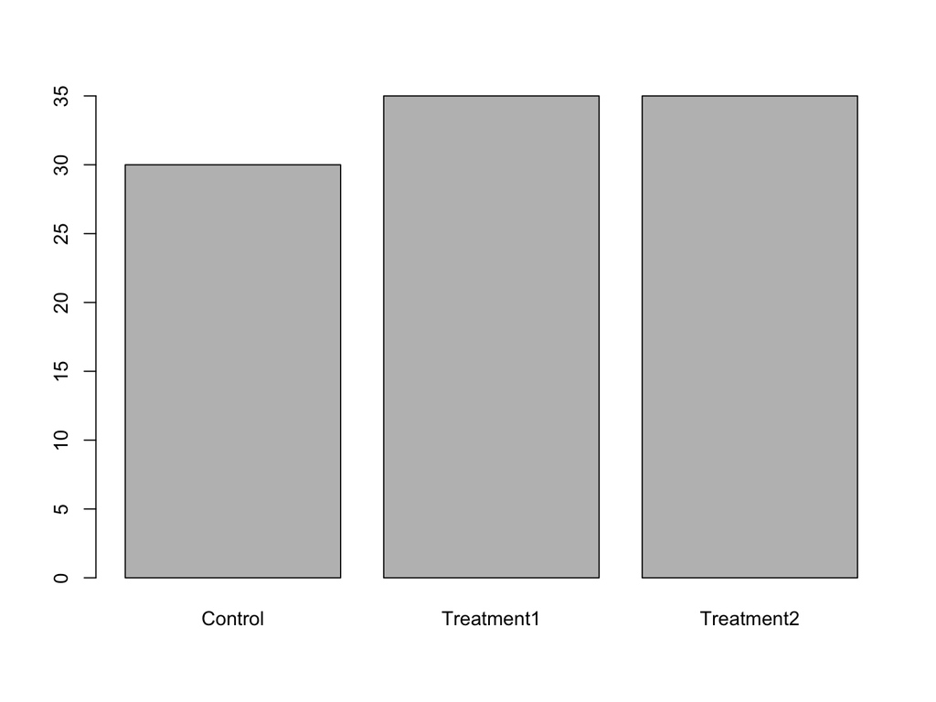

```r
barplot(table(d$Group))
```

- **Exercice**: use `factor()` to modify the order and plot the control group last

# Factors: solution

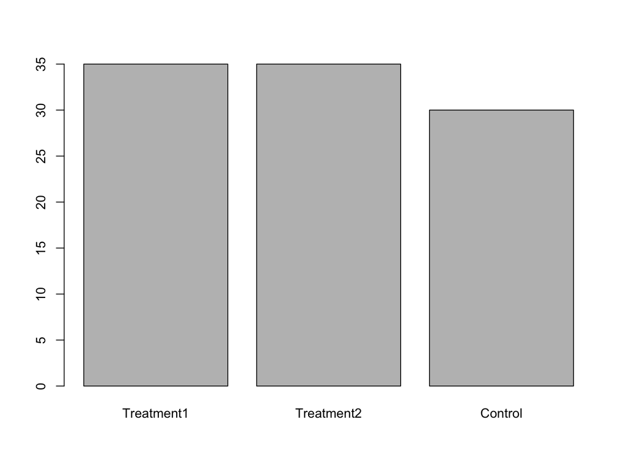

```r
# use the indexing [-1] to remove the first element of levels(d$Group), then combine via c()
d$Group <- factor(d$Group, levels = c(levels(d$Group)[-1], levels(d$Group)[1]))
barplot(table(d$Group))
```

# Working with factors

- Clearly the gender entry has been coded with errors:

```r
table(d$Gender)
```

```
##
##  f  F  m  M
## 35  4 46 15
```

- `F` and `M` should have been recorded as `f` and `m`

```r
d$Gender[d$Gender == "M"] <- "m"
table(d$Gender)
```

```
##
##  f  F  m  M
## 35  4 61  0
```

```r
d$Gender <- droplevels(d$Gender)
table(d$Gender)
```

```
##
##  f  F  m
## 35  4 61
```

- *Shortcut*: can directly use the `levels()` function

```r
levels(d$Gender)[2] <- "f"
table(d$Gender)
```

```
##
##  f  m
## 39 61
```